# Cross-tissue senescence hub-gene study in type 2 diabetes: results report

Computational study, human GEO microarray data; assembled from saved results only

# Summary

- **Islet arm.** Nested-CV AUC 0.659 (95% CI 0.528-0.789, sample-level bootstrap). The apparent AUC of the full-cohort model on its own training data is 0.766 and is optimistic. The final panel is a single gene, **IL1R1**. On independent islets (GSE76894, n = 99) the frozen model gives AUC 0.591 (0.435-0.738): the interval includes 0.5, so the discovery signal is **not demonstrated to replicate**. The secondary islet set (GSE20966, n = 20) gives 0.560 (0.290-0.820), also including 0.5.
- **Adipose arm.** Nested-CV AUC 0.532 (0.384-0.682): indistinguishable from chance. The apparent AUC is 0.871. The final panel is a single gene, **SNAI1**. External validation (GSE71416, n = 17) gives AUC 0.439 (0.136-0.742), and the direction of effect is opposite to discovery in both adipose validation sets. **The adipose result is a null result.**
- Of the four headline numbers, **1 of 4** has a confidence interval that excludes 0.5 (islet nested CV).
- **Cross-tissue.** No shared gene between the two panels; the overlap is not a finding (primary permutation p = 1.000, which is 1 by construction when the observed overlap is 0).
- **Docking was not performed**: under protocol 5.4 the only candidate (IL1R1, stability 0.42) fails criterion (a), stability >= 0.5.
- Sensitivity analyses show the panels are unstable. The islet AUC rises when 11 label-discordant donors are removed, but that is a hypothesis, not a finding.

# 1. Study design and data

Two parallel arms (islet, adipose): discovery, then a nested-CV-validated hub-gene panel (senescence gene union screened by limma, then LASSO, SVM-RFE and Boruta/Random Forest, intersected, then a ridge classifier), then a single frozen-model pass on external cohorts. Followed by cross-tissue comparison, enrichment, single-cell specificity (islet only) and a docking target rule. Specification: `docs/Methodology_Protocol_v1.md` (v1.2). Human microarray data from NCBI GEO; no wet-lab component.

## 1.1 Cohorts and final sample sizes

Cohorts, final sample sizes after exclusions. Acquired = counts verified at download (manifest/count_verification.csv); final = from the QC-passed phenotype tables (data/processed/04_*_pheno.rds).

| Role | Accession | Tissue, platform | Acquired | Final analysed | Exclusions |
| --- | --- | --- | --- | --- | --- |
| Islet discovery | GSE41762 | Whole islets, GPL6244 | 57 ND / 20 T2D | 57 ND / 20 T2D (n = 77) | none |
| Islet external validation, primary | GSE76894 | Whole islets (IMIDIA donors), GPL570 | 84 ND / 19 T2D (n = 103) | 80 ND / 19 T2D (n = 99) | 4 ND donors excluded for possible overlap with GSE41762/GSE20966 (protocol v1.1) |
| Islet external validation, secondary | GSE20966 | LCM beta-cells, GPL1352 | 10 ND / 10 T2D | 10 ND / 10 T2D (n = 20) | none |
| Islet single-cell (descriptive) | GSE81608 | Islet cells, GPL16791 (SMARTer, RPKM only) | 651 ND / 949 T2D cells (1600) | 559 ND / 852 T2D cells post-QC (n = 1411); 12 ND / 6 T2D donors | MAD-based cell QC (section 7) |
| Adipose discovery | GSE27951 (GPL570) | Subcutaneous adipose, GPL570 | 11 ND / 12 T2D (+ 10 IGT) | 11 ND / 12 T2D (n = 23) | 10 IGT samples excluded (project-lead decision; neither group) |
| Adipose external validation | GSE71416 | Omental adipose, morbidly obese, GPL570 | 6 ND / 14 T2D | 6 ND / 11 T2D (n = 17) | 3 arrays excluded, median NUSE > 1.05 (protocol 2.3) |
| Adipose direction-only | GSE16415 | Visceral adipose, GPL2986 | 5 ND / 5 T2D | 5 ND / 5 T2D (n = 10) | none |
| Islet ‘sensitivity’ (RETIRED) | GSE38642 | Whole islets, GPL6244 | 54 ND / 9 T2D (n = 63) | 0 (not used) | RETIRED (protocol v1.1): all 63 CEL files byte-identical to GSE41762 arrays; not independent data |

Notes on group definitions and data handling. GSE27951: group from the GEO `clinical status` field (NGT = ND, DM = T2D, IGT excluded); three samples (GSM691135, GSM691139, GSM691140) have title/field discordance, the field is used, and a sensitivity rerun covers the PCA outlier (section 4). GSE71416: group from sample titles (no disease field in GEO). GSE41762: all 77 arrays normalised together; the submitters’ donor 1-48 / 49-80 split is carried as the covariate `submitter_norm_batch`. Each GSE is normalised independently; no cross-cohort batch correction anywhere.

**GSE38642 retirement.** Task 2 showed that all 63 of its CEL files are byte-identical (decompressed MD5) to arrays of GSE41762, so it provides no independent data. 11 donors carry a different diabetes label in GSE38642 than in GSE41762 (10 ND in GSE38642 but T2D in GSE41762; 1 the reverse). That discordance is handled as a pre-specified sensitivity analysis (section 4) and is also a limitation (section 9).

Exclusions by dataset and reason (summarised from logs/excluded_samples.csv; the full list is in section 10).

| Dataset | Reason | n arrays excluded |
| --- | --- | --- |
| GSE27951 | IGT, user decision 2026-10-03 | 10 |
| GSE71416 | median NUSE 1.0586 > 1.05 (protocol 2.3) | 1 |
| GSE71416 | median NUSE 1.1393 > 1.05 (protocol 2.3) | 1 |
| GSE71416 | median NUSE 1.3207 > 1.05 (protocol 2.3) | 1 |
| GSE76894 | possible donor overlap, protocol v1.1 | 4 |

## 1.2 Protocol lock timeline

Protocol lock tags (git tag / git log at report time).

| Tag | Commit | Date | Subject |
| --- | --- | --- | --- |
| protocol-v1 | 7018fc2 | 2026-10-05 00:04:41 +0530 | Lock methodology protocol v1 and pre-analysis plan |
| protocol-v1.1 | 9d87d91 | 2026-10-05 00:13:46 +0530 | Protocol amendment v1.1: retire GSE38642, add GSE76894 islet validation |
| protocol-v1.2 | 1e19c02 | 2026-10-05 23:54:07 +0530 | Task 6: descriptive DEGs and islet WGCNA; adipose WGCNA stopped by pre-set rule; protocol v1.2 (docking rule 5.4b) |

Full commit history, oldest first.

| Commit | Date | Subject |
| --- | --- | --- |
| 7018fc2 | 2026-10-05 00:04 | Lock methodology protocol v1 and pre-analysis plan |
| 9d87d91 | 2026-10-05 00:13 | Protocol amendment v1.1: retire GSE38642, add GSE76894 islet validation |
| 5a7a0a9 | 2026-10-05 00:26 | Add GSE76894 acquisition and donor-overlap check; exclude 4 possible-overlap donors |
| b2c604a | 2026-10-05 21:14 | Task 3: normalisation, QC, and QC decisions (pre-analysis plan B12) |
| cda2050 | 2026-10-05 21:17 | Task 4: senescence gene-set union (1151 genes, HGNC-mapped) |
| 39c6df9 | 2026-10-05 22:07 | Task 5: nested CV engine and islet run (permutation + synthetic controls passed; Boruta NaN warning under review) |
| 3a7b5bb | 2026-10-05 22:31 | Task 5 review: Boruta warning diagnosed as benign; headline CI choice logged |
| 43681f4 | 2026-10-05 23:08 | Task 5b: adipose nested CV, permutation test, and four pre-specified sensitivity runs |
| 1e19c02 | 2026-10-05 23:54 | Task 6: descriptive DEGs and islet WGCNA; adipose WGCNA stopped by pre-set rule; protocol v1.2 (docking rule 5.4b) |
| 9712502 | 2026-10-06 00:02 | Task 7: final panels and one-shot external validation (locked) |
| a57cf16 | 2026-10-06 00:27 | Tasks 8-9: cross-tissue comparison, enrichment, single-cell pseudobulk |

Validation lock file (`results/stage5/09_VALIDATION_SCORED.lock`) first line: `validation scored: 2026-10-06 00:01:19 IST`. Tag `protocol-v1.2` precedes the scoring time, so the docking-rule amendment (5.4b) was made before any validation set was scored. Report rendered at git HEAD `a57cf16`; this report file itself is not part of that commit.

Stated at lock time (protocol header): all GEO files had been downloaded and sample metadata inspected; no expression values had been normalised or analysed when `protocol-v1` and `protocol-v1.1` were tagged. Pre-analysis plan: `docs/pre_analysis_plan.md`.

# 2. Headline results

The four numbers. Nested-CV AUC is honest and is the headline (CLAUDE.md rule 5); the apparent AUC (full-cohort model scored on its own training data) is optimistic and appears only beside it. Two 95% CIs per number: **headline** = sample-level stratified bootstrap (2000 replicates); **protocol** = `pROC::ci.auc` (2000 stratified bootstraps). For the discovery arms the protocol CI is computed on pooled out-of-fold predictions of all repeats and is too narrow (the repeats are not independent); the headline interval is the more conservative one (`logs/deviations.md`, 2026-10-05). For the external cohorts there is one prediction per sample, so the two intervals come out identical in the saved file.

Headline table: four numbers, each with 95% CI, beside the optimistic apparent AUC for the discovery arms.

| Number | Cohort | n (T2D) | Panel | AUC | 95% CI headline (bootstrap) | 95% CI protocol (pROC) | Optimistic apparent AUC [pROC 95% CI] | CI excludes 0.5? |
| --- | --- | --- | --- | --- | --- | --- | --- | --- |
| 1. Islet nested CV | GSE41762 (discovery) | 77 (20) | IL1R1 | 0.659 | 0.528-0.789 | 0.596-0.726 | 0.766 [0.625-0.882] | yes |
| 2. Islet external | GSE76894 (primary external) | 99 (19) | IL1R1 | 0.591 | 0.435-0.738 | 0.435-0.738 | n/a (external) | no |
| 3. Adipose nested CV | GSE27951 (discovery) | 23 (12) | SNAI1 | 0.532 | 0.384-0.682 | 0.439-0.593 | 0.871 [0.667-1.000] | no |
| 4. Adipose external | GSE71416 (external) | 17 (11) | SNAI1 | 0.439 | 0.136-0.742 | 0.136-0.742 | n/a (external) | no |

Secondary external (GSE20966) and direction-only (GSE16415) cohorts.

| Cohort | n (T2D) | Panel | AUC | 95% CI headline (bootstrap) | 95% CI protocol (pROC) |
| --- | --- | --- | --- | --- | --- |
| GSE20966 (secondary islet external) | 20 (10) | IL1R1 | 0.560 | 0.290-0.820 | 0.290-0.820 |
| GSE16415 (adipose, direction only) | 10 (5) | SNAI1 | not computed (protocol 7: direction only) | n/a | n/a |

Direction of effect of the single panel gene in each validation cohort (information only; it informs no decision). The sign test is degenerate for a one-gene panel (two-sided p = 1 in every row of the saved file).

| Validation cohort | Gene | Discovery cohort | Direction in discovery | Direction in validation | Concordant | Welch t p (descriptive) |
| --- | --- | --- | --- | --- | --- | --- |
| GSE76894 | IL1R1 | GSE41762 | up in T2D | up in T2D | TRUE | 0.162 |
| GSE20966 | IL1R1 | GSE41762 | up in T2D | up in T2D | TRUE | 0.538 |
| GSE71416 | SNAI1 | GSE27951 | down in T2D | up in T2D | FALSE | 0.893 |
| GSE16415 | SNAI1 | GSE27951 | down in T2D | up in T2D | FALSE | 0.971 |

Plain reading.

- **Islet.** Nested-CV AUC 0.659 (0.528-0.789) is above chance under both interval methods, and is well below the apparent AUC of 0.766. The panel is one gene (IL1R1), selected in only 0.42 of outer folds. External AUC is 0.591 in GSE76894 (0.435-0.738) and 0.560 in GSE20966 (0.290-0.820). The sign of the effect matches discovery in both, but both intervals include 0.5. The most the data support is a weak, unreplicated islet signal.
- **Adipose.** Nested-CV AUC 0.532 with an interval centred on 0.5 under both methods; the apparent AUC of 0.871 is overfitting of a one-gene model on 23 samples. External AUC 0.439 (0.136-0.742) is below 0.5 and the direction of the gene is opposite to discovery in GSE71416 and GSE16415. There is no adipose result.

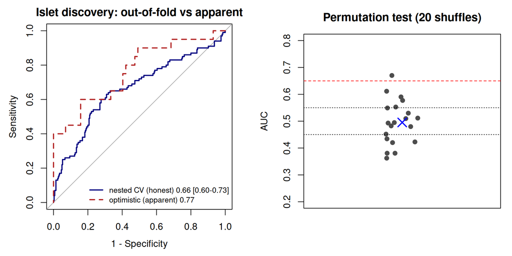

Islet discovery: out-of-fold (nested CV, honest) versus apparent (optimistic) ROC, and the 20-shuffle permutation test. *(source: results/stage3/figures/06_islet_roc_permutation.png)*

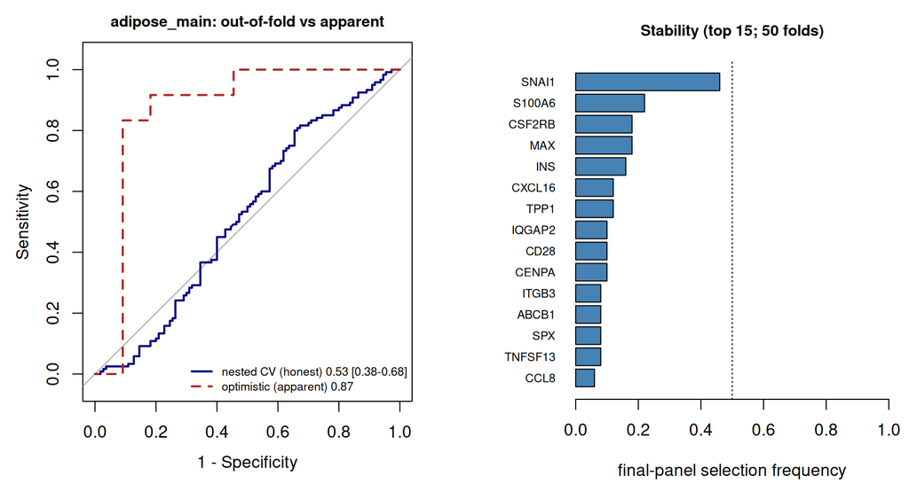

Adipose discovery: nested-CV versus apparent ROC, and final-panel selection frequency (top 15, 50 folds). *(source: results/stage3/figures/06b_adipose_main_roc_stability.png)*

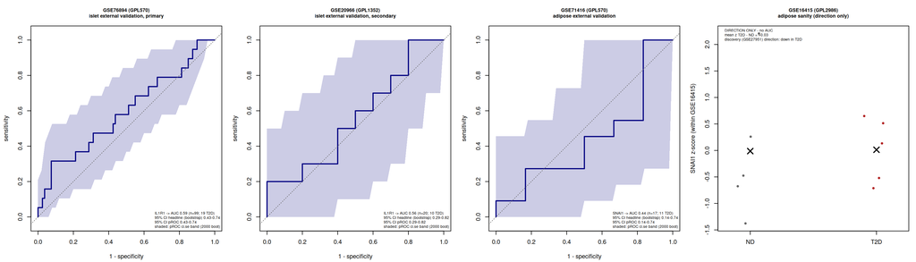

External validation, one frozen-model pass: GSE76894, GSE20966, GSE71416 (ROC with pROC ci.se bands) and GSE16415 (direction only). *(source: results/stage5/figures/09_external_validation_roc.png)*

# 3. Leakage controls

Three controls were run on the discovery arms before any validation data were touched (protocol section 3 self-tests): no sample index in both train and test of a fold; the matrix passed to limma in each fold has exactly the training-fold size (both are hard assertions in `scripts/06_nested_cv.R`); a label-permutation test of the full pipeline; plus a synthetic positive control.

## 3.1 Permutation tests

Permutation test: 20 independent label shuffles, full pipeline, 1 outer repeat each (summarised from the saved per-shuffle AUCs).

| Arm | Shuffles | Mean AUC | SD | Min | 95th percentile | Max | Pass (mean in [0.45, 0.55] and 95th pct < 0.65) |
| --- | --- | --- | --- | --- | --- | --- | --- |
| Islet (GSE41762) | 20 | 0.495 | 0.082 | 0.362 | 0.614 | 0.670 | pass |
| Adipose (GSE27951) | 20 | 0.477 | 0.136 | 0.250 | 0.642 | 0.742 | pass |

Both arms pass the pre-set criterion, so the nested-CV engine shows no sign of leakage. The adipose 95th percentile (0.642) is close to the 0.65 limit; with 23 samples the null distribution of AUC is wide (individual shuffles reach 0.742), which is a further reason the adipose AUC of 0.532 carries no information.

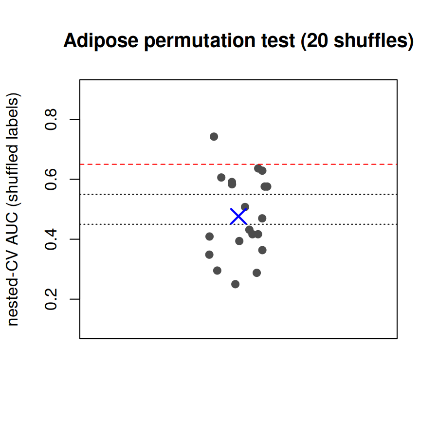

Adipose permutation null (20 shuffles). *(source: results/stage3/figures/06b_adipose_permutation.png)*

## 3.2 Synthetic positive control (islet engine)

Design (as logged in `logs/06_nested_cv_20261005_212648.log`, fixed before running): 3000 genes, 77 samples with the real ND/T2D labels, 10 randomly chosen senescence-union genes shifted by +1.5 SD in T2D, everything else noise, covariates independent of status; production pipeline, 10-fold x 2 repeats. Pre-stated pass: nested AUC >= 0.90 and >= 8 of the top-10 stability genes planted.

Result: nested-CV AUC 0.984 (protocol CI 0.968-0.995; sample-level CI 0.962-0.997); 9 of 10 planted genes are in the top 10 by stability; pass flag in the saved object: **PASS**. The pipeline therefore recovers a real signal when one exists. One planted gene (KDR) was not recovered (frequency 0.00).

Planted genes and their final-panel selection frequency in the synthetic run.

| Planted gene | Final-panel frequency |
| --- | --- |
| MSRA | 1.00 |
| CD34 | 0.95 |
| GHRHR | 0.95 |
| FERMT1 | 0.90 |
| PPIB | 0.90 |
| ORAI1 | 0.90 |
| RAP1GAP | 0.75 |
| CACNA1A | 0.75 |
| AKT1 | 0.55 |
| KDR | 0.00 |

## 3.3 Boruta warning diagnosis

During the Task 5 islet run Boruta 10.0.0 (default `fru` importance backend) emitted “getImp result contains NA(s)” in 47 of 50 folds. Diagnosis as logged in `logs/deviations.md` (2026-10-05; evidence in `results/stage3/diagnostics/`): NaN occurs only in the first ~15 of 499 iterations and is replaced by 0, so it cannot create a false confirmation. The production backend was kept for both arms, and a robustness check swapping in ranger importance gave the same final panel, the same top-3 stability genes and a nested AUC of 0.662 versus 0.659. This was a benign warning, reported, not a defect that changes any result.

Saved diagnostic output, quoted:

```
iterations: 499  with NaN: 15
FINAL fit, Boruta backend fru: panel = IL1R1 (L0_intersection); LASSO 3, SVM-RFE 11, Boruta 24
features_k, production vs ranger-swap: identical in 40/50 folds; Jaccard mean 0.957; fallback level identical in 50/50; levels swap: L0 32 vs prod 32
ranger-swap nested AUC per repeat: 0.661 0.665 0.648 0.667 0.668  mean 0.662 (production 0.659)
```

# 4. Sensitivity analyses (pre-specified, protocol section 8)

Pre-specified sensitivity runs next to the main run. Islet: excluding the 11 GSE41762/GSE38642 label-discordant donors (excl11); adding BMI. Adipose: excluding PCA outlier GSM691134; adding BMI.

| Arm | Run | n (T2D) | Final panel | Nested AUC | CI headline | CI protocol | Apparent (optimistic) | Nested AUC minus main | Panel genes shared with main | Panel-gene stability |
| --- | --- | --- | --- | --- | --- | --- | --- | --- | --- | --- |
| islet | islet_main (reference) | 77 (20) | IL1R1 | 0.659 | 0.528-0.789 | 0.596-0.726 | 0.766 | - | - | IL1R1:0.42 |
| islet | islet_excl11 | 66 (10) | SERPINE2, PCGF2, CD55, SFRP1 | 0.788 | 0.686-0.880 | 0.720-0.844 | 0.938 | +0.128 | none | SERPINE2:0.92, PCGF2:0.60, CD55:0.54, SFRP1:0.40 |
| islet | islet_bmi | 77 (20) | IL1R1, EPOR, PCK1, NLK, FXN | 0.666 | 0.526-0.801 | 0.595-0.727 | 0.948 | +0.007 | IL1R1 | IL1R1:0.46, EPOR:0.38, PCK1:0.54, NLK:0.60, FXN:0.28 |
| adipose | adipose_main (reference) | 23 (12) | SNAI1 | 0.532 | 0.384-0.682 | 0.439-0.593 | 0.871 | - | - | SNAI1:0.46 |
| adipose | adipose_excl_GSM691134 | 22 (12) | PEA15, SPX, CSF2RB, ITGB3, IQGAP2, HSPB1, INS, NRSN2 | 0.416 | 0.269-0.564 | 0.350-0.498 | 0.950 | -0.116 | none | PEA15:0.18, SPX:0.10, CSF2RB:0.16, ITGB3:0.20, IQGAP2:0.02, HSPB1:0.06, INS:0.08, NRSN2:0.04 |
| adipose | adipose_bmi | 23 (12) | SNAI1 | 0.511 | 0.373-0.650 | 0.429-0.579 | 0.871 | -0.021 | SNAI1 | SNAI1:0.36 |

Plain reading.

- **Adipose: not robust.** Dropping one sample (GSM691134) changes the final panel completely (no shared gene), moves the nested AUC from 0.532 to 0.416 (below 0.5; interval 0.269-0.564), and the apparent AUC rises to 0.950 with an eight-gene panel. Adding BMI keeps the panel gene but leaves the AUC at chance (0.511). The adipose arm has no stable result.
- **Islet: the +BMI run is stable, the excl-11 run is a hypothesis.** Adding BMI leaves nested AUC essentially unchanged (0.666 vs 0.659); the panel grows to five genes and retains IL1R1. Excluding the 11 label-discordant donors raises the nested AUC to 0.788 (0.686-0.880), but the panel changes entirely (SERPINE2, PCGF2, CD55, SFRP1; no gene shared with the main panel), the run has only 10 T2D donors, and 10 of the 11 excluded donors are labelled T2D in GSE41762 (so excluding them removes half of that cohort’s 20 T2D labels). The gain could reflect cleaner labels, a smaller and different cohort, or chance. **It is a hypothesis, not a finding.** It was a pre-specified descriptive run; it informed no decision and the headline stays on the main run.
- Across runs the panels are single genes or small sets that do not carry over; the more reproducible quantity is the stability ranking (section 5), and even that moves between runs.

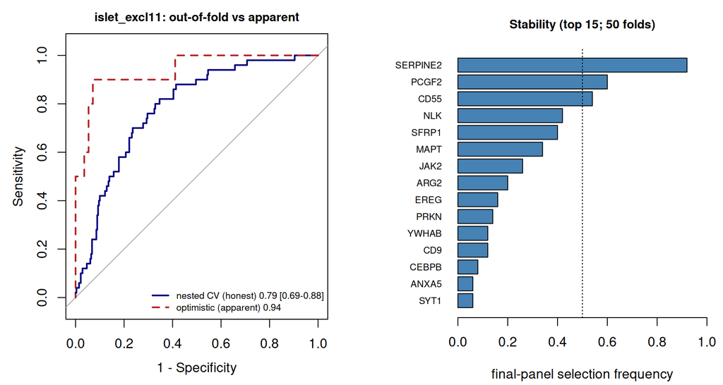

Islet sensitivity run excluding the 11 label-discordant donors (ROC and stability). *(source: results/stage3/figures/06b_islet_excl11_roc_stability.png)*

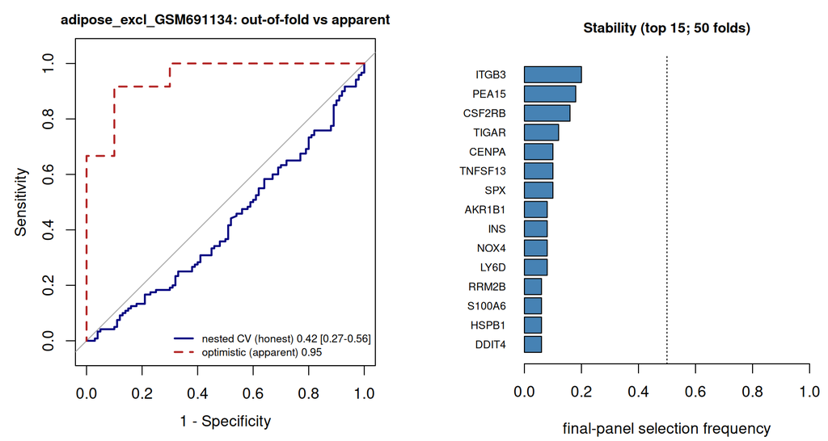

Adipose sensitivity run excluding GSM691134 (ROC and stability). *(source: results/stage3/figures/06b_adipose_excl_GSM691134_roc_stability.png)*

# 5. Descriptive DEGs, WGCNA and stability genes

Descriptive full-cohort limma (BH FDR < 0.05 and abs(log2FC) >= 0.263) and WGCNA are descriptive/corroborative only; neither chooses the panel (protocol 3.3, 4.1).

Descriptive differential expression (07a). Adipose: no gene reaches FDR < 0.05.

| Arm | Cohort | n (T2D) | Genes tested | FDR<0.05 | DEGs (FDR and FC) | Up / down | Senescence-union genes tested | Senescence DEGs |
| --- | --- | --- | --- | --- | --- | --- | --- | --- |
| islet | GSE41762 | 77 (20) | 14721 | 74 | 62 | 29 / 33 | 1000 | 11 |
| adipose | GSE27951 | 23 (12) | 16416 | 0 | 0 | 0 / 0 | 1029 | 0 |

## 5.1 Islet WGCNA (GSE41762, n = 77)

Soft threshold beta = 13 (first beta in 1-20 with signed scale-free R^2 >= 0.85; R^2 = 0.858). 16 modules; 1 kept (abs(r) > 0.3 and p < 0.05 against status); 2 hubs (kME > 0.8, abs(GS) > 0.2, and a senescence-union DEG).

The one kept islet module.

| Module | n genes | r (status) | p (status) | r (BMI) | p (BMI) | Flagged possibly confounded |
| --- | --- | --- | --- | --- | --- | --- |
| lightcyan (label 16) | 33 | 0.361 | 0.001 | 0.231 | 0.043 | yes: BMI |

Hub genes of the kept module.

| Gene | Module | kME | GS (status) | GS p | DEG log2FC | DEG BH adj p | Module possibly confounded |
| --- | --- | --- | --- | --- | --- | --- | --- |
| GPC3 | lightcyan | 0.878 | 0.411 | 2.04e-04 | 0.626 | 0.046 | yes (BMI) |
| FGF2 | lightcyan | 0.865 | 0.399 | 3.29e-04 | 0.618 | 0.045 | yes (BMI) |

Hubs are **GPC3 and FGF2**. The kept module’s eigengene is also correlated with BMI (p = 0.043), so it is flagged as possibly BMI-confounded. **IL1R1, the nested-CV panel gene, is not in any module** (assigned to the grey/unassigned set, label 0; MAD rank 1088 of the full matrix, so it was eligible; kME and hub status not defined; gene significance for status 0.432, p = 8.87e-05). The WGCNA hubs and the ML panel therefore do not coincide. GPC3 and FGF2 had nested-CV stability of 0.02 and 0.02 respectively (islet).

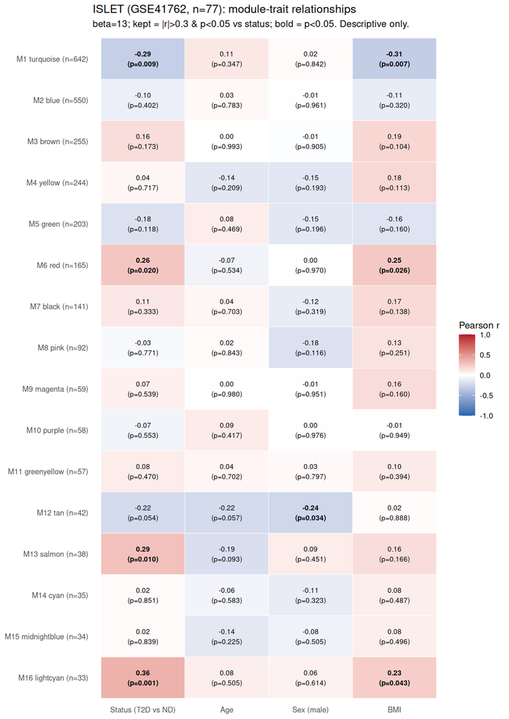

Islet module-trait heatmap (eigengene versus status, age, sex, BMI). *(source: results/stage4/figures/07_module_trait_islet.png)*

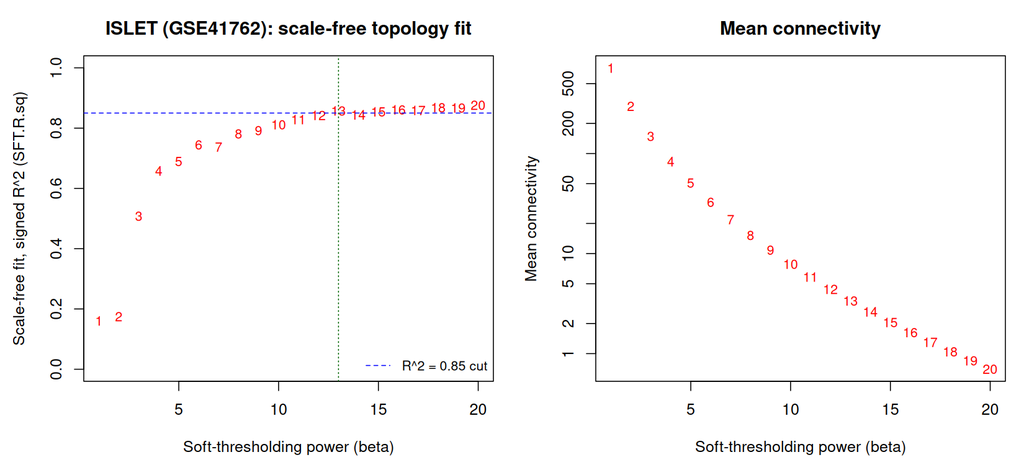

Islet scale-free fit (signed R^2) versus soft threshold. *(source: results/stage4/figures/07_scalefree_islet.png)*

## 5.2 Adipose WGCNA: stopped by the pre-set rule (GSE27951, n = 23)

**The adipose WGCNA was stopped.** No soft threshold in 1-20 reached scale-free R^2 >= 0.85; the best was R^2 = 0.764 at beta = 20 (n = 23). Per protocol 4.1 the curve is reported, no beta was chosen, and no modules, trait analysis or bootstrap stability analysis were run. The threshold was not lowered. WGCNA is reported as not feasible at this sample size; the adipose arm is described by the nested-CV result alone. Verdict text from `07_verdicts.csv`: “ADIPOSE ARM STOPPED at the soft-threshold step (STOP: no beta in 1..20 reaches scale-free R^2 >= 0.85 (signed R^2); best = 0.764 at beta = 20. Curve saved; NO beta chosen; no modules, no trait analysis, no stability run.) Stability analysis (100 bootstraps) and adipose module-trait analysis NOT run; adipose WGCNA therefore yields no modules and is not reported (protocol §4.1: never pick a beta silently).”

Adipose soft-threshold curve at selected betas (full curve in the figure and in results/stage4/07_softthreshold_adipose.csv).

| beta | Signed scale-free R^2 | Slope | Mean connectivity | R^2 >= 0.85 |
| --- | --- | --- | --- | --- |
| 1 | 0.119 | 0.26 | 1202.9 | no |
| 5 | 0.700 | -1.01 | 185.2 | no |
| 10 | 0.724 | -1.29 | 48.3 | no |
| 15 | 0.745 | -1.44 | 18.0 | no |
| 20 | 0.764 | -1.54 | 8.1 | no |

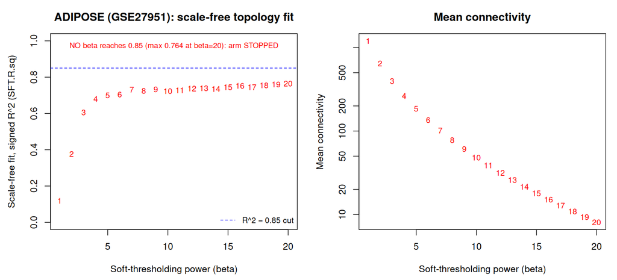

Adipose scale-free fit versus soft threshold: no beta reaches 0.85. *(source: results/stage4/figures/07_scalefree_adipose.png)*

## 5.3 Stability genes (top 20 per arm)

Selection frequency = fraction of the 50 outer folds in which the gene was in the fold’s final panel (features_k); component columns give the frequency passing the screen and each learner.

Islet (GSE41762): top 20 genes by stability.

| Rank | Gene | Final-panel freq. | Screen | LASSO | SVM-RFE | Boruta |
| --- | --- | --- | --- | --- | --- | --- |
| 1 | SERPINE2 | 0.70 | 1.00 | 0.34 | 1.00 | 1.00 |
| 2 | NLK | 0.52 | 1.00 | 0.46 | 0.58 | 0.96 |
| 3 | IL1R1 | 0.42 | 1.00 | 0.36 | 0.52 | 1.00 |
| 4 | PCK1 | 0.36 | 1.00 | 0.50 | 0.50 | 0.76 |
| 5 | CDKN1A | 0.32 | 0.96 | 0.12 | 0.64 | 0.60 |
| 6 | FXN | 0.28 | 1.00 | 0.34 | 0.74 | 0.46 |
| 7 | EPOR | 0.24 | 1.00 | 0.44 | 0.72 | 0.46 |
| 8 | ARG2 | 0.24 | 1.00 | 0.16 | 0.42 | 0.90 |
| 9 | CEBPB | 0.22 | 1.00 | 0.32 | 0.34 | 0.88 |
| 10 | SFRP1 | 0.18 | 1.00 | 0.14 | 0.60 | 0.36 |
| 11 | PLAUR | 0.16 | 1.00 | 0.28 | 0.14 | 0.98 |
| 12 | CD9 | 0.16 | 1.00 | 0.24 | 0.30 | 1.00 |
| 13 | NUTF2 | 0.14 | 1.00 | 0.22 | 0.28 | 0.82 |
| 14 | PCGF2 | 0.08 | 1.00 | 0.06 | 0.30 | 0.36 |
| 15 | MYCN | 0.08 | 0.24 | 0.04 | 0.16 | 0.22 |
| 16 | CD55 | 0.08 | 0.74 | 0.02 | 0.26 | 0.72 |
| 17 | MAPT | 0.06 | 1.00 | 0.12 | 0.18 | 0.08 |
| 18 | RACK1 | 0.06 | 1.00 | 0.12 | 0.14 | 1.00 |
| 19 | PEA15 | 0.06 | 1.00 | 0.04 | 0.22 | 0.30 |
| 20 | MYBBP1A | 0.04 | 1.00 | 0.30 | 0.58 | 0.04 |

Adipose (GSE27951): top 20 genes by stability.

| Rank | Gene | Final-panel freq. | Screen | LASSO | SVM-RFE | Boruta |
| --- | --- | --- | --- | --- | --- | --- |
| 1 | SNAI1 | 0.46 | 0.58 | 0.12 | 0.44 | 0.58 |
| 2 | S100A6 | 0.22 | 0.78 | 0.00 | 0.24 | 0.76 |
| 3 | CSF2RB | 0.18 | 0.84 | 0.12 | 0.08 | 0.82 |
| 4 | MAX | 0.18 | 0.44 | 0.02 | 0.18 | 0.34 |
| 5 | INS | 0.16 | 0.80 | 0.06 | 0.16 | 0.68 |
| 6 | CXCL16 | 0.12 | 0.54 | 0.08 | 0.14 | 0.22 |
| 7 | TPP1 | 0.12 | 0.66 | 0.06 | 0.08 | 0.66 |
| 8 | IQGAP2 | 0.10 | 0.84 | 0.06 | 0.18 | 0.50 |
| 9 | CD28 | 0.10 | 0.10 | 0.04 | 0.10 | 0.10 |
| 10 | CENPA | 0.10 | 0.88 | 0.04 | 0.70 | 0.14 |
| 11 | ITGB3 | 0.08 | 0.62 | 0.06 | 0.30 | 0.22 |
| 12 | ABCB1 | 0.08 | 0.58 | 0.02 | 0.34 | 0.16 |
| 13 | SPX | 0.08 | 0.80 | 0.00 | 0.16 | 0.26 |
| 14 | TNFSF13 | 0.08 | 0.22 | 0.00 | 0.08 | 0.22 |
| 15 | CCL8 | 0.06 | 0.36 | 0.02 | 0.06 | 0.26 |
| 16 | HAS1 | 0.06 | 0.42 | 0.02 | 0.14 | 0.06 |
| 17 | PEA15 | 0.06 | 0.92 | 0.02 | 0.14 | 0.44 |
| 18 | CXCL12 | 0.06 | 0.68 | 0.00 | 0.06 | 0.26 |
| 19 | DDIT4 | 0.06 | 0.50 | 0.00 | 0.26 | 0.04 |
| 20 | FERMT1 | 0.06 | 0.56 | 0.00 | 0.14 | 0.10 |

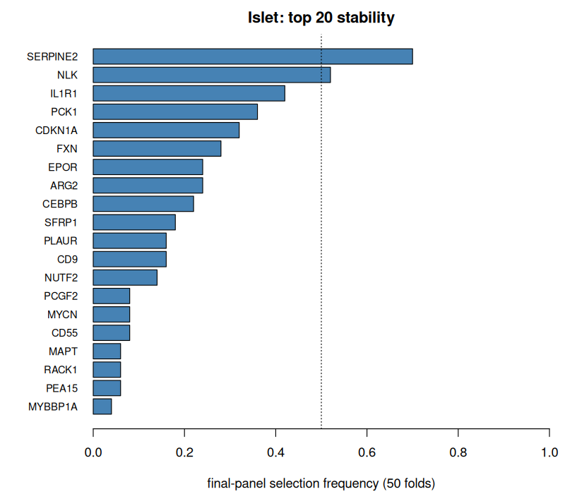

islet stability bars drawn from the saved stability table (dotted line = 0.5, the docking threshold).

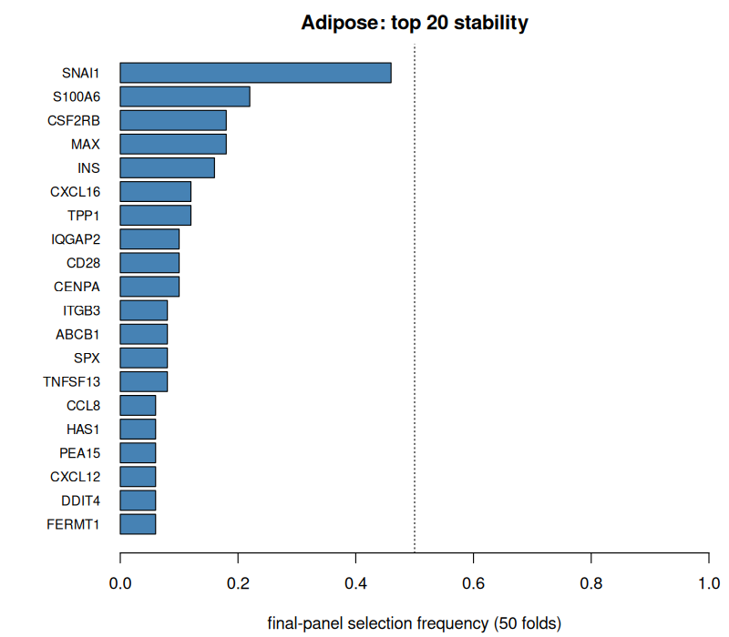

adipose stability bars drawn from the saved stability table (dotted line = 0.5, the docking threshold).

Only two islet genes (SERPINE2, NLK) reach selection frequency 0.5 and neither is the final panel gene; no adipose gene reaches 0.5. The final-panel gene in each arm is the output of a single full-cohort fit, whereas stability measures how often a gene survives across resampled training sets; the two are different quantities and here they disagree about the ranking.

# 6. Cross-tissue comparison and enrichment

## 6.1 Cross-tissue verdict

Cross-tissue comparison (10_overlap_summary.csv).

| Item | Value |
| --- | --- |
| Islet final panel | IL1R1 |
| Adipose final panel | SNAI1 |
| Overlap of final panels | 0 |
| Islet screen+LASSO selection (true labels, full cohort) | IL1R1;PCK1;PLAUR |
| Adipose screen+LASSO selection (true labels, full cohort) | (empty) |
| OBSERVED overlap of screen+LASSO selections (primary statistic) | 0 |
| Permutation repeats | 1000 |
| count(null >= observed) | 1000 |
| PRIMARY empirical p (permutation) | 1.0000 |
| Hypergeometric universe size N | 931 |
| SECONDARY hypergeometric p (final panels) | 1 |
| Overlap of stability lists (freq >= 0.2), descriptive | 0 |

**Verdict (verbatim from the saved file):**

> NO OVERLAP: the islet final panel (IL1R1) and the adipose final panel (SNAI1) share no gene, and the screen+LASSO selections share no gene (observed overlap 0; primary permutation p = 1.0000, which equals 1 by construction when the observed overlap is 0; hypergeometric on the final panels p = 1). No cross-tissue overlap is reported as a finding; no shared hub-gene is claimed.

**Degenerate-permutation caveat.** The observed overlap is 0, so every one of the 1000 permutations satisfies null >= observed and the primary p equals 1 by construction; the test cannot discriminate in this situation. What it can show is the null itself: the overlap was 0 in 991 of 1000 permutations and 1 in 9 (never larger), so even a single shared gene would have had an empirical p of roughly 0.010. The same applies to the hypergeometric test (p = 1 for an overlap of 0). Neither test supports, or could have supported, a claim of shared hub genes here. Stated plainly: **there is no cross-tissue overlap, and nothing is reported as a shared hub gene.**

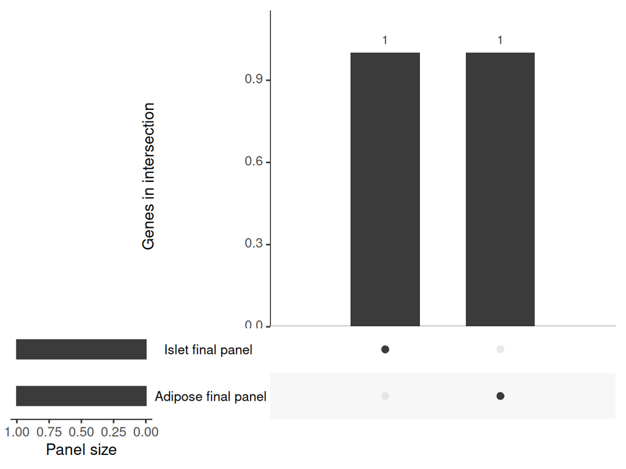

UpSet plot of the two final panels (no intersection). *(source: results/stage6/figures/10_upset_final_panels.png)*

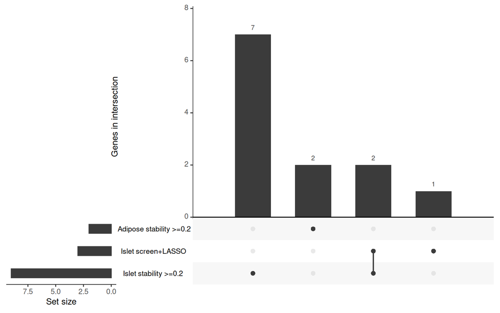

UpSet plot of the screen+LASSO selection sets and stability lists. *(source: results/stage6/figures/10_upset_selection_sets.png)*

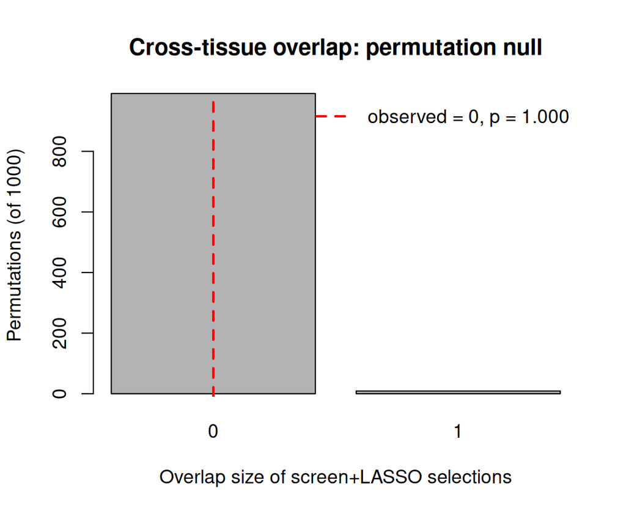

Permutation null for the overlap size (1000 permutations; observed = 0). *(source: results/stage6/figures/10_permutation_null.png)*

## 6.2 Enrichment

Protocol enrichment (section 5.2): all three sets are below the 10-gene minimum.

| Set | Genes | Universe (expressed genes) | Status |
| --- | --- | --- | --- |
| shared | 0 | 18255 | underpowered (<10 genes): not tested |
| islet-specific | 1 | 14721 | underpowered (<10 genes): not tested |
| adipose-specific | 1 | 16416 | underpowered (<10 genes): not tested |

Gene-level annotation of the two panel genes (underpowered sets are annotated narratively instead of tested; Entrez/GO/KEGG from org.Hs.eg.db as saved in 11_gene_annotation_summary.csv).

| Gene | Name | Cytoband | Set | GO BP/MF/CC terms | Senescence list | KEGG pathways | Islet DE (log2FC; BH p; DEG) | Adipose DE (log2FC; BH p; DEG) | Stability (islet / adipose) |
| --- | --- | --- | --- | --- | --- | --- | --- | --- | --- |
| IL1R1 | interleukin 1 receptor type 1 | 2q11.2-q12.1 | islet-specific | 19/14/10 | CellAge | hsa04010 MAPK signaling pathway; hsa04060 Cytokine-cytokine receptor interaction; hsa04064 NF-kappa B signaling pathway; hsa04380 Osteoclast differentiation; hsa04640 Hematopoietic cell lineage; hsa04… | 0.613; 0.017; TRUE | 0.506; 0.606; FALSE | 0.42 / 0.00 |
| SNAI1 | snail family transcriptional repressor 1 | 20q13.13 | adipose-specific | 50/15/12 | CellAge | hsa04520 Adherens junction | 0.223; 0.379; FALSE | -0.268; 0.488; FALSE | 0.00 / 0.46 |

The shared set is empty and the islet-specific and adipose-specific sets each contain one gene (IL1R1 and SNAI1), so **enrichment testing is underpowered and was not performed** (protocol 5.2). Gene-level annotation only: IL1R1 (interleukin 1 receptor type 1) is annotated to cytokine/NF-kB and MAPK signalling and is in CellAge; it is a descriptive DEG in islets (BH p 0.017) but not in adipose. SNAI1 (snail family transcriptional repressor 1) is a transcriptional repressor annotated to adherens-junction biology and is in CellAge; it is not a descriptive DEG in adipose (no adipose gene passes FDR < 0.05). Both genes are single entries in one senescence database (CellAge) and their annotation is not evidence that they are mechanistic drivers.

EXPLORATORY analysis E1 (not in the protocol): the 11 islet senescence-union DEGs. Background A = all expressed islet genes; background B = senescence-union genes expressed in islet.

| Background | DB | Genes | Universe size | Terms tested | Significant (BH < 0.05) |
| --- | --- | --- | --- | --- | --- |
| A: all expressed islet genes | GO_BP | 11 | 14721 | 1006 | 219 |
| A: all expressed islet genes | GO_MF | 11 | 14721 | 59 | 20 |
| A: all expressed islet genes | GO_CC | 11 | 14721 | 37 | 2 |
| A: all expressed islet genes | KEGG | 11 | 14721 | 101 | 17 |
| B (caveat): senescence-union genes expressed in islet | GO_BP | 11 | 1000 | 1087 | 35 |
| B (caveat): senescence-union genes expressed in islet | GO_MF | 11 | 1000 | 101 | 2 |
| B (caveat): senescence-union genes expressed in islet | GO_CC | 11 | 1000 | 78 | 3 |
| B (caveat): senescence-union genes expressed in islet | KEGG | 11 | 1000 | 90 | 5 |

E1: top 3 terms per background and database.

| Background | DB | Term | Count | BH p | Genes |
| --- | --- | --- | --- | --- | --- |
| A | GO_BP | morphogenesis of a branching epithelium | 5 | 1.01e-04 | MYC, FGF2, GPC3, FGF7, HGF |
| A | GO_BP | morphogenesis of a branching structure | 5 | 1.01e-04 | MYC, FGF2, GPC3, FGF7, HGF |
| A | GO_BP | ureteric bud development | 4 | 1.16e-04 | ARG2, MYC, FGF2, GPC3 |
| A | GO_CC | side of membrane | 5 | 4.21e-04 | IL1R1, PDGFRA, PLAUR, FAS, GPC3 |
| A | GO_CC | external side of plasma membrane | 4 | 4.21e-04 | IL1R1, PDGFRA, PLAUR, FAS |
| A | GO_CC | RNA polymerase II transcription repressor complex | 1 | 0.088 | MYC |
| A | GO_MF | chemoattractant activity | 3 | 3.33e-05 | FGF2, FGF7, HGF |
| A | GO_MF | growth factor receptor binding | 4 | 3.33e-05 | IL1R1, PDGFRA, FGF2, FGF7 |
| A | GO_MF | platelet-derived growth factor receptor binding | 2 | 9.18e-04 | IL1R1, PDGFRA |
| A | KEGG | MAPK signaling pathway | 7 | 5.29e-06 | 3554, 4609, 5156, 355, 2247, 2252, 3082 |
| A | KEGG | Proteoglycans in cancer | 6 | 1.14e-05 | 4609, 5329, 355, 2247, 2719, 3082 |
| A | KEGG | Melanoma | 4 | 7.77e-05 | 5156, 2247, 2252, 3082 |
| B | GO_BP | response to external stimulus | 11 | 0.004 | IL1R1, ARG2, MYC, PDGFRA, PCK1, PLAUR, FAS, FGF2, GPC3, FGF7, HGF |
| B | GO_BP | morphogenesis of a branching epithelium | 5 | 0.030 | MYC, FGF2, GPC3, FGF7, HGF |
| B | GO_BP | morphogenesis of a branching structure | 5 | 0.030 | MYC, FGF2, GPC3, FGF7, HGF |
| B | GO_CC | side of membrane | 5 | 0.008 | IL1R1, PDGFRA, PLAUR, FAS, GPC3 |
| B | GO_CC | external side of plasma membrane | 4 | 0.008 | IL1R1, PDGFRA, PLAUR, FAS |
| B | GO_CC | cell surface | 5 | 0.029 | IL1R1, PDGFRA, PLAUR, FAS, GPC3 |
| B | GO_MF | growth factor receptor binding | 4 | 0.019 | IL1R1, PDGFRA, FGF2, FGF7 |
| B | GO_MF | chemoattractant activity | 3 | 0.032 | FGF2, FGF7, HGF |
| B | GO_MF | signaling receptor activity | 4 | 0.091 | IL1R1, PDGFRA, PLAUR, FAS |
| B | KEGG | MAPK signaling pathway | 7 | 0.008 | 3554, 4609, 5156, 355, 2247, 2252, 3082 |
| B | KEGG | Proteoglycans in cancer | 6 | 0.008 | 4609, 5329, 355, 2247, 2719, 3082 |
| B | KEGG | PI3K-Akt signaling pathway | 6 | 0.031 | 4609, 5156, 5105, 2247, 2252, 3082 |

E1 is exploratory and hypothesis-generating only. The 11 genes were chosen from the senescence union, so with the whole expressed genome as universe (background A) enrichment for growth-factor and development terms is inflated by that pre-selection; background B (senescence-union genes expressed in islets) removes that bias and is the appropriate one, and it still yields 45 terms across the four databases (versus 258 under A). With 11 genes, few of which are independent (the same handful of FGF/GPC3/HGF/MYC genes recur across terms), these counts should not be read as pathway discoveries. E2/E3 (islet stability list, freq >= 0.2: 9 genes; adipose: 2 genes; adipose DEGs: 0) were also below 10 genes and not tested.

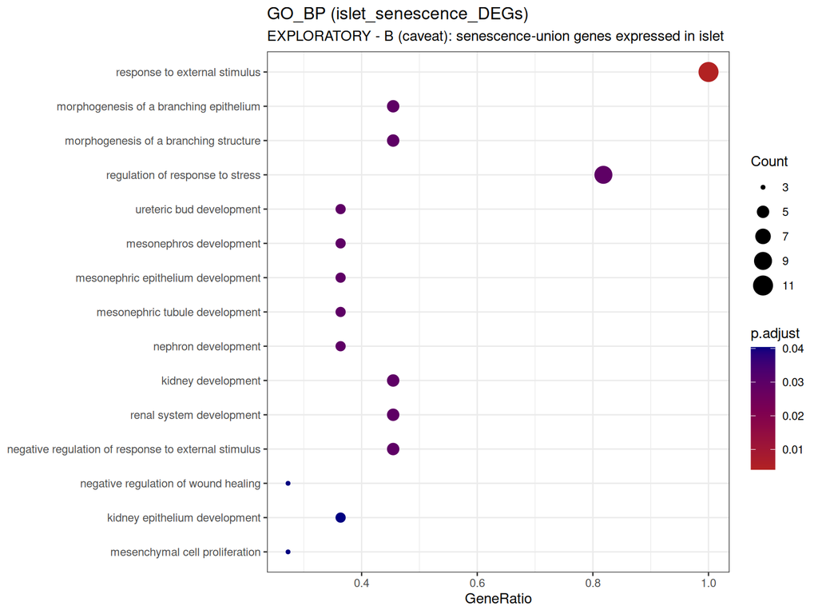

E1 (exploratory), background B: GO biological process. *(source: results/stage6/figures/11_islet_senescence_DEGs_bgB_unionExpressed_GO_BP_dotplot.png)*

# 7. Single-cell specificity (GSE81608)

GSE81608 is descriptive and discovery-adjacent data, not validation; it informs no panel decision. Cell types are the authors’ labels. All statistics are donor-level pseudobulk; no per-cell tests.

Cell QC by group (MAD-based, 3 MADs on log genes detected, log library size and mitochondrial fraction).

| Group | Cells | Removed | Kept | % removed |
| --- | --- | --- | --- | --- |
| ND | 651 | 92 | 559 | 14.1 |
| T2D | 949 | 97 | 852 | 10.2 |

Cell QC by cell type.

| Cell type (authors’ label) | Cells | Removed | Kept | % removed |
| --- | --- | --- | --- | --- |
| PP | 93 | 18 | 75 | 19.4 |
| alpha | 946 | 58 | 888 | 6.1 |
| beta | 503 | 97 | 406 | 19.3 |
| delta | 58 | 16 | 42 | 27.6 |

Donors per group and cell type with at least 10 post-QC cells (the pre-set pseudobulk threshold). Delta and PP are not testable.

| Cell type | ND donors (>= 10 cells) | T2D donors (>= 10 cells) | Donors | Testable |
| --- | --- | --- | --- | --- |
| beta | 6 | 5 | 11 | yes |
| alpha | 10 | 6 | 16 | yes |
| delta | 0 | 0 | 0 | no |
| PP | 1 | 1 | 2 | no |

Marker check of the authors’ labels (INS, GCG, SST, PPY as expected; PRSS1/COL1A1 have no matching label in the deposit).

| Marker | Expected cell type | Highest-expressing label | As expected |
| --- | --- | --- | --- |
| INS | beta | beta | True |
| GCG | alpha | alpha | True |
| SST | delta | delta | True |
| PPY | PP | PP | True |
| PRSS1 | none present (acinar/stellate labels absent) | delta | n/a |
| COL1A1 | none present (acinar/stellate labels absent) | delta | n/a |

Post-QC cells: 1411 of 1600 retained. Donors: 12 ND and 6 T2D contributed cells; with the >= 10-cell rule, beta cells have 6 ND / 5 T2D donors and alpha cells 10 ND / 6 T2D donors. **The T2D arm is 5 to 6 donors.** Delta cells (maximum 8 cells in any donor) and PP cells (1 ND / 1 T2D donor) cannot be tested.

Detection fraction / mean log2(RPKM+1) per cell type, all post-QC cells (genes of interest: both panel genes, top-5 islet stability genes, WGCNA hubs).

| Gene | Category | beta (det. / mean) | alpha (det. / mean) | delta (det. / mean) | PP (det. / mean) |
| --- | --- | --- | --- | --- | --- |
| IL1R1 | nested-CV panel | 0.15 / 0.39 | 0.31 / 0.77 | 0.12 / 0.25 | 0.16 / 0.30 |
| SNAI1 | nested-CV panel | 0.01 / 0.03 | 0.02 / 0.06 | 0.07 / 0.13 | 0.01 / 0.09 |
| SERPINE2 | top islet stability | 0.26 / 0.79 | 0.81 / 3.48 | 0.24 / 0.98 | 0.57 / 2.22 |
| NLK | top islet stability | 0.34 / 0.81 | 0.24 / 0.58 | 0.26 / 0.67 | 0.29 / 0.70 |
| CDKN1A | top islet stability | 0.62 / 3.12 | 0.28 / 0.86 | 0.26 / 0.81 | 0.60 / 2.83 |
| PCK1 | top islet stability | 0.02 / 0.03 | 0.06 / 0.23 | 0.19 / 1.01 | 0.00 / 0.00 |
| FXN | top islet stability | 0.11 / 0.19 | 0.18 / 0.31 | 0.10 / 0.07 | 0.15 / 0.38 |
| GPC3 | WGCNA hub | 0.00 / 0.00 | 0.00 / 0.00 | 0.05 / 0.18 | 0.00 / 0.00 |
| FGF2 | WGCNA hub | 0.03 / 0.04 | 0.05 / 0.05 | 0.05 / 0.07 | 0.03 / 0.01 |

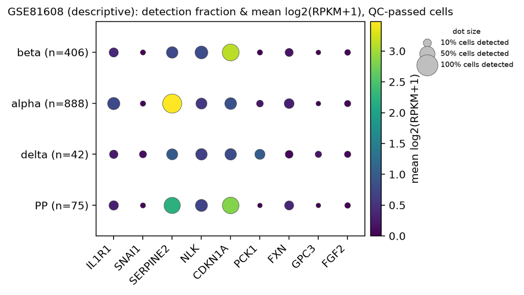

Single-cell dot plot: detection fraction and mean expression by cell type. *(source: results/stage7/figures/12_dotplot_genes_by_celltype.png)*

Pseudobulk T2D versus ND, primary model per cell type (limma on donor-level mean log2(RPKM+1)). Beta: unadjusted model (an age/sex-adjusted model was not estimable with 11 donors); alpha: adjusted model. Both are in the saved file.

| Cell type | Model | Gene | n ND / T2D | log2FC (T2D vs ND) | P | BH (9 genes) | Min. detectable \|log2FC\| (80% power) | Note |
| --- | --- | --- | --- | --- | --- | --- | --- | --- |
| alpha | adjusted | IL1R1 | 10 / 6 | 0.194 | 0.285 | 0.699 | 0.51 |  |
| alpha | adjusted | SNAI1 | 10 / 6 | 0.039 | 0.107 | 0.699 | 0.07 |  |
| alpha | adjusted | SERPINE2 | 10 / 6 | -0.192 | 0.646 | 0.963 | 1.20 |  |
| alpha | adjusted | NLK | 10 / 6 | -0.007 | 0.963 | 0.963 | 0.42 |  |
| alpha | adjusted | CDKN1A | 10 / 6 | 0.174 | 0.350 | 0.699 | 0.53 |  |
| alpha | adjusted | PCK1 | 10 / 6 | 0.015 | 0.861 | 0.963 | 0.25 |  |
| alpha | adjusted | FXN | 10 / 6 | 0.108 | 0.202 | 0.699 | 0.24 |  |
| alpha | adjusted | GPC3 | 10 / 6 | n/a | n/a | n/a | n/a | gene not fitted (pseudobulk > 0 in < 3 donors) |
| alpha | adjusted | FGF2 | 10 / 6 | 0.001 | 0.959 | 0.963 | 0.08 |  |
| beta | unadjusted | IL1R1 | 6 / 5 | -0.164 | 0.249 | 0.836 | 0.42 |  |
| beta | unadjusted | SNAI1 | 6 / 5 | n/a | n/a | n/a | n/a | gene not fitted (pseudobulk > 0 in < 3 donors) |
| beta | unadjusted | SERPINE2 | 6 / 5 | 0.010 | 0.969 | 0.969 | 0.75 |  |
| beta | unadjusted | NLK | 6 / 5 | -0.160 | 0.437 | 0.836 | 0.62 |  |
| beta | unadjusted | CDKN1A | 6 / 5 | 0.230 | 0.703 | 0.836 | 1.85 |  |
| beta | unadjusted | PCK1 | 6 / 5 | 0.024 | 0.472 | 0.836 | 0.10 |  |
| beta | unadjusted | FXN | 6 / 5 | 0.054 | 0.571 | 0.836 | 0.29 |  |
| beta | unadjusted | GPC3 | 6 / 5 | n/a | n/a | n/a | n/a | gene not fitted (pseudobulk > 0 in < 3 donors) |
| beta | unadjusted | FGF2 | 6 / 5 | 0.032 | 0.716 | 0.836 | 0.27 |  |

Beta-cell restriction verdicts (protocol 5.3 rule: significant in beta pseudobulk and not significant in alpha or delta).

| Gene | Category | Beta | Alpha | Delta | Verdict |
| --- | --- | --- | --- | --- | --- |
| IL1R1 | nested-CV panel | not significant | not significant | not testable | INCONCLUSIVE (not significant in beta pseudobulk; low power, not evidence of no effect) |
| SNAI1 | nested-CV panel | not testable | not significant | not testable | NOT ASSESSABLE (beta not testable for this gene) |
| SERPINE2 | top islet stability | not significant | not significant | not testable | INCONCLUSIVE (not significant in beta pseudobulk; low power, not evidence of no effect) |
| NLK | top islet stability | not significant | not significant | not testable | INCONCLUSIVE (not significant in beta pseudobulk; low power, not evidence of no effect) |
| CDKN1A | top islet stability | not significant | not significant | not testable | INCONCLUSIVE (not significant in beta pseudobulk; low power, not evidence of no effect) |
| PCK1 | top islet stability | not significant | not significant | not testable | INCONCLUSIVE (not significant in beta pseudobulk; low power, not evidence of no effect) |
| FXN | top islet stability | not significant | not significant | not testable | INCONCLUSIVE (not significant in beta pseudobulk; low power, not evidence of no effect) |
| GPC3 | WGCNA hub | not testable | not testable | not testable | NOT ASSESSABLE (beta not testable for this gene) |
| FGF2 | WGCNA hub | not significant | not significant | not testable | INCONCLUSIVE (not significant in beta pseudobulk; low power, not evidence of no effect) |

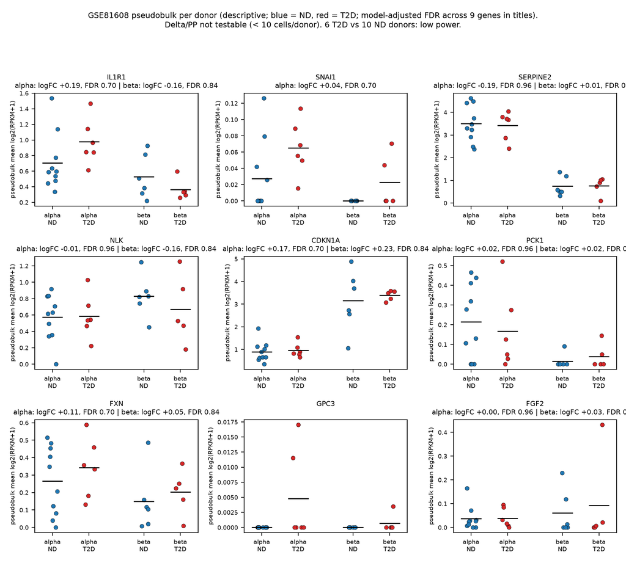

Donor-level pseudobulk expression, beta and alpha cells. *(source: results/stage7/figures/12_pseudobulk_beta_alpha_genes.png)*

**Reading: no gene is shown to be beta-cell restricted; every verdict is inconclusive or not assessable.** No gene reaches FDR < 0.05 in beta pseudobulk (smallest BH value 0.836), and the approximate minimum detectable effects in beta cells range from 0.10 to 1.85 log2 units across the panel genes (80% power, 6 ND vs 5 T2D donors), so absence of significance is **not** evidence of no effect. Because delta cells have no testable donors, the delta arm of the restriction rule cannot be assessed at all, so no gene could be declared fully beta-restricted even in principle. SNAI1 is detected in only 0.012 of beta cells and GPC3 is not fitted in beta or alpha (pseudobulk non-zero in fewer than 3 donors). IL1R1 is detected in 0.15 of beta cells and 0.31 of alpha cells, i.e. it is not beta-specific in expression.

**Deviations affecting this section** (full wording in section 10): GSE81608 on GEO has only an RPKM matrix, so pseudobulk is the mean of log2(RPKM+1) per donor and cell type tested with limma (no voom/edgeR on counts), which is less well calibrated than count-based pseudobulk; and the >= 10 cell threshold was not relaxed, so delta and PP pseudobulk tests were not performed.

# 8. Docking

**Docking was NOT performed.** Under protocol 5.4 the candidate set is the shared panel genes and, when there are none, the islet final panel. There are no shared genes (section 6), so the only candidate is **IL1R1**, with nested-CV selection frequency **0.42**. Criterion (a) requires frequency >= 50%, so IL1R1 fails (a) and, per 5.4 item 4, “docking is reported as not performed under the rule. The rule is not relaxed.” The structure criterion (c) was not assessed, because (a) already excludes the candidate. No docking results exist and none are shown here. (Criterion (b) was amended in protocol v1.2 to information only; the direction in validation was concordant in both islet cohorts, but that is not a selection criterion.)

Ligand files were acquired from PubChem and are in `ligands/` (embelin_CID3218_3D.sdf, embelin_CID3218_smiles.csv, LSC_NEEDED_FROM_LAB.md, naringenin_CID932_3D.sdf, naringenin_CID932_smiles.csv, rutin_CID5280805_3D.sdf, rutin_CID5280805_smiles.csv, SOURCES.md): naringenin (CID 932), embelin (CID 3218), rutin (CID 5280805). **The lead small compound (LSC) structure is still needed from the lab** (`ligands/LSC_NEEDED_FROM_LAB.md`); it has not been guessed or substituted.

Any docking performed later would be **exploratory** and could not be presented as following from the pre-specified rule. The only genes with stability >= 0.5 are SERPINE2 and NLK (islet; stability 0.70 and 0.52), and neither is in the final panel. If docking is run on them it must be labelled as outside protocol 5.4, with the controls of protocol 6.4 (redocking RMSD < 2 A; 40 property-matched decoys per ligand; delta-G reported as a decoy percentile). A docking score would predict binding geometry, not affinity or biological effect.

# 9. Limitations

Stated without softening.

1. **Adipose discovery n = 23 (11 ND / 12 T2D) is underpowered.** It is too small for WGCNA (the arm stopped: no soft threshold reached R^2 >= 0.85) and too small for a stable ML panel (the panel changed completely when one sample was dropped). The adipose validation cohort GSE71416 was reduced by NUSE exclusion to n = 17 (6 ND / 11 T2D); its interval spans most of the AUC range.
2. **The validation cohorts are small and the intervals are wide.** GSE20966 (n = 20), GSE71416 (n = 17) and GSE16415 (n = 10) are tiny; GSE76894 (n = 99, 19 T2D) is larger but its interval (0.435-0.738) still includes 0.5. None of the external AUCs is distinguishable from chance.
3. **GSE38642 is the same set of arrays as GSE41762** (63/63 CEL files byte-identical) and was retired; it provides no independent validation. **11 donors have discordant diabetes labels** between the two GEO deposits (10 of them are T2D in GSE41762, i.e. half of that cohort’s T2D labels), and donor ID30 has a discordant sex. Which deposit is correct is unknown. GSE41762 labels were used for the main analysis.
4. **Bulk adipose cannot resolve the driving cell type.** Adipose tissue is a mixture of adipocytes, stromal and immune cells; a gene-level signal in bulk may reflect composition differences. No adipose single-cell data were analysed.
5. **Cross-platform transfer attenuates the islet validation.** The islet model was trained on GPL6244 (HuGene 1.0 ST) and applied to GPL570 (GSE76894) and GPL1352 (GSE20966) after z-scoring within each cohort; probe-set coverage, dynamic range and platform effects can reduce discriminative performance independently of biology, so a weaker external AUC is expected even for a real signal.
6. **Docking, if ever done, predicts geometry, not affinity.** It was not done here (section 8).
7. **All data are cross-sectional.** No causal or temporal inference is possible; senescence markers could be cause, consequence, or correlate of T2D, of treatment, or of obesity.
8. **Single-gene panels are unstable.** Both final panels are one gene (IL1R1, SNAI1), selected in 42% and 46% of outer folds respectively; sensitivity runs produced different panels with no shared gene in two of four comparisons (section 4). A one-gene ridge classifier is a univariate marker, not a multi-gene signature.
9. **GSE81608 has only RPKM values and few T2D donors** (5 to 6 per testable cell type); delta and PP cells are untestable. Pseudobulk on mean log RPKM is less calibrated than count pseudobulk.
10. **A vacuous assertion was left in `scripts/09_external_validation.R`** (`... | TRUE`, which always passes). Editing the script after scoring would have changed its MD5 against the validation lock, so it was left in place. The other assertions are real and the dry run reproduced the stored apparent AUCs exactly (`logs/deviations.md`, 2026-10-06).
11. **SenMayo is 124 genes, not 125.** The paper’s 125-gene list (Saul 2022, Supplementary Data 1) was not retrievable; the MSigDB 124-gene copy was used and the discrepancy is **unresolved** (recorded in `logs/05_genesets_20261005_211636.log`; the saved gene-set summary shows 124 SenMayo symbols).
12. **Sex calls are XIST-free for GSE41762 and GSE16415** (no XIST probe on those annotations; Y-gene mean only; deviation logged). GSE27951 has no recorded sex in GEO, so its sex covariate is expression-inferred. Two recorded-versus-inferred mismatches (GSE41762 ID30, GSE20966 GSM524170) were kept using the inferred value.
13. **Multiple analyses on small cohorts.** The sensitivity runs and the exploratory analyses (E1, E2, E3, the 11-donor exclusion) are descriptive, and none of them should be quoted as a finding.

# 10. Deviations and exclusions

## 10.1 Deviations log (verbatim from `logs/deviations.md`)

| Date | Item | Original | Changed to | Reason |
| --- | --- | --- | --- | --- |
| 2026-10-03 | Boruta package version | latest CRAN (10.0.0) | 8.0.0, then **reverted to 10.0.0** the same day | v10 needs the Rust compiler (via `fru`). Pinned to 8.0.0 temporarily; cargo 1.93.1 was then installed and Boruta 10.0.0 installed. No deviation remains in effect. Recorded before any analysis ran. |
| 2026-10-03 | Adipose discovery cohort definition (GSE27951) | 11 ND / 10 T2D, n=21 (protocol/proposal) | GPL570 subseries, IGT excluded: 11 ND / 12 T2D, n=23 | GEO holds 33 human GPL570 samples (11 NGT / 10 IGT / 12 DM), not 21. IGT samples fit neither group. PI-level decision by the project owner (option 1). Group taken from the clinical-status field; 3 sam… |
| 2026-10-05 | Methodology protocol | `docs/Methodology_Protocol_v1.md` referenced by CLAUDE.md but never written | Authored and locked 2026-10-05 (tag `protocol-v1`) | Written after GEO download and metadata inspection, before any expression data was normalised or analysed. Stated in the protocol header. |
| 2026-10-05 | Task 5 permutation self-test | 1 shuffle, accept AUC 0.40-0.60 | 20 shuffles; mean in 0.45-0.55, 95th pct < 0.65 | Single shuffle fails by chance ~19% (null SD ~0.075 at 20 vs 57). Changed before Task 5 was run. |
| 2026-10-05 | GSE27951 discordant labels | “awaiting PI confirmation” | Clinical-status field final; sensitivity rerun excluding GSM691135, GSM691140 | Decision by project lead. |
| 2026-10-05 | GSE38642 role (protocol v1.1) | Non-overlapping donors as direction-of-effect sensitivity check | Retired, not used | Task 2: 63/63 GSE38642 CELs byte-identical (decompressed MD5) to the same-ID GSE41762 CELs; “unique” samples are relabelled copies. Decided before any expression analysis. |
| 2026-10-05 | Islet external validation (protocol v1.1) | GSE20966 only (n=20) | GSE76894 primary (84 ND / 19 T2D, n=103, GPL570, PMID 29185012); GSE20966 secondary | GSE38642 offers no independent data; n=20 gives an uninformative CI. Added by project lead before any expression analysis; donor-overlap check precedes scoring. |
| 2026-10-05 | GSE41762 label discordance (protocol v1.1) | not anticipated | GSE41762 status field used; sensitivity rerun excluding 11 discordant donors | 10 donors ND in GSE38642 but T2D in GSE41762, 1 the reverse; ID30 sex differs. |
| 2026-10-05 | Sex check input (protocol §2.4), GSE41762 and GSE16415 only | XIST vs mean(RPS4Y1, DDX3Y, KDM5D, UTY), k-means k=2 | k-means k=2 on the Y-gene mean alone (GSE41762: RPS4Y1, DDX3Y, KDM5D, UTY; GSE16415: RPS4Y1, DDX3Y, UTY) | XIST has no transcript cluster in `hugene10sttranscriptcluster.db` 8.8.0 and no probe in the GPL2986 annotation table, so it is absent from the collapsed matrices built with the §2.2 annotation source… |
| 2026-10-05 | QC outcomes (Task 3) | protocol §2.3 flags PCA outliers for project-lead decision | GSM691134 kept, sensitivity rerun added; inferred sex used for ID30 and GSM524170; GSE71416 n=17 accepted; see pre-analysis plan B12 | Decisions made from QC evidence only; not parameter relaxations. |
| 2026-10-05 | Boruta importance backend (Task 5) | not named in protocol §3 step 4 | Boruta 10.0.0 default (`fru`, getImpFruZ) kept for both arms | “getImp result contains NA(s)” warning in 47/50 folds is benign (NaN only in the first ~15 of 499 iterations; replaced by 0, cannot create a false confirmation). Sensitivity check with `getImpRfZ` (ra… |
| 2026-10-05 | Headline CI for nested-CV AUC (protocol §3) | CI from pooled predictions of all repeats (pROC ci.auc, 2000 bootstraps) | Headline = sample-level stratified bootstrap CI (islet 0.528-0.789); protocol CI (0.596-0.726) reported beside it | Pooled CI treats the 5 repeats as independent although every donor appears in each repeat, so it is too narrow. The headline is the more conservative interval; stricter, not relaxed. |
| 2026-10-05 | Docking rule 5.4(b) (protocol v1.2) | target must show same direction of effect in external validation | Direction in validation reported for information only; not a selection criterion | The original rule would use validation data to make a decision, contradicting CLAUDE.md rule 2. Amended BEFORE any validation set was scored. |
| 2026-10-05 | Adipose WGCNA (Task 6, protocol §4.1) | n/a: stop rule | **Arm stopped**: no soft threshold 1..20 reached R^2 >= 0.85 (best 0.764 at beta=20, n=23) | Pre-specified stop rule applied as written; no beta picked, no modules, no stability run. Adipose is described by the nested-CV result only; WGCNA reported as not feasible at this sample size. |
| 2026-10-06 | Validation scoring (Task 7, scripts/09_external_validation.R) | n/a | Scored once on 2026-10-06 00:01 IST; lock `results/stage5/09_VALIDATION_SCORED.lock`; `--verify-identical` passed | Note: one vacuous assertion (`... \| TRUE`) left in 09 because editing the script after scoring would change its md5 against the lock. Harmless; the other assertions are real and the dry run reproduce… |
| 2026-10-06 | GSE81608 pseudobulk input (Task 9, scripts/12_singlecell.py (RPKM)) | protocol §5.3: pseudobulk = sum of raw counts per donor x cell type; limma-voom or edgeR | Pseudobulk = mean of log2(RPKM+1) over a donor’s cells of one cell type; limma lmFit + eBayes on that log-scale matrix (no voom: no counts) | GEO deposit GSE81608 contains only the RPKM matrix, no raw counts. RPKM is length- and depth-normalised, so summing is not valid for voom/edgeR; means of log values are the closest available analogue.… |
| 2026-10-06 | GSE81608 delta and PP cell types (Task 9, scripts/12_singlecell.py (delta/PP)) | protocol §5.3: restriction = significant in beta and NOT significant in alpha or delta; donors with >= 10 cells kept | Threshold NOT relaxed (>= 10 cells). Consequence: delta (max 8 cells in any donor) has no testable donors and PP has too few donors per group (< 2 ND) -> delta/PP pseudobulk tests not performed; the d… | Data limitation, not a parameter change. Recorded so it is not mistaken for a null result. |

## 10.2 Excluded samples (verbatim from `logs/excluded_samples.csv`)

All excluded samples.

| GSM | Dataset | Reason | Date |
| --- | --- | --- | --- |
| GSM691126 | GSE27951 | IGT, user decision 2026-10-03 | 2026-10-03 |
| GSM691127 | GSE27951 | IGT, user decision 2026-10-03 | 2026-10-03 |
| GSM691128 | GSE27951 | IGT, user decision 2026-10-03 | 2026-10-03 |
| GSM691132 | GSE27951 | IGT, user decision 2026-10-03 | 2026-10-03 |
| GSM691139 | GSE27951 | IGT, user decision 2026-10-03 | 2026-10-03 |
| GSM691145 | GSE27951 | IGT, user decision 2026-10-03 | 2026-10-03 |
| GSM691146 | GSE27951 | IGT, user decision 2026-10-03 | 2026-10-03 |
| GSM691149 | GSE27951 | IGT, user decision 2026-10-03 | 2026-10-03 |
| GSM691151 | GSE27951 | IGT, user decision 2026-10-03 | 2026-10-03 |
| GSM691152 | GSE27951 | IGT, user decision 2026-10-03 | 2026-10-03 |
| GSM2040064 | GSE76894 | possible donor overlap, protocol v1.1 | 2026-10-05 |
| GSM2040077 | GSE76894 | possible donor overlap, protocol v1.1 | 2026-10-05 |
| GSM2040120 | GSE76894 | possible donor overlap, protocol v1.1 | 2026-10-05 |
| GSM2040122 | GSE76894 | possible donor overlap, protocol v1.1 | 2026-10-05 |
| GSM1833927 | GSE71416 | median NUSE 1.3207 > 1.05 (protocol 2.3) | 2026-10-05 |
| GSM1833937 | GSE71416 | median NUSE 1.1393 > 1.05 (protocol 2.3) | 2026-10-05 |
| GSM1833938 | GSE71416 | median NUSE 1.0586 > 1.05 (protocol 2.3) | 2026-10-05 |

# 11. Reproducibility

- **renv.lock:** R 4.5.2; Bioconductor 3.22; 245 packages (50 from Bioconductor). Lock taken on first run and not updated mid-project (CLAUDE.md). CLAUDE.md requires R >= 4.4 and Bioconductor >= 3.20; the lock satisfies both.
- **Seed policy (CLAUDE.md):** every script calls `set.seed(42)` before any stochastic step; per-fold seeds in the nested-CV engine derive deterministically from 42 (fold-specific offsets); permutation shuffles use fixed offsets (4200 + i; see scripts). The scan below checks each script for a seed-42 call; `00_install.R` is the package installer and has no stochastic step.

Key package versions from renv.lock.

| Package | Version | Source |
| --- | --- | --- |
| limma | 3.66.0 | Bioconductor |
| glmnet | 5.1 | Repository |
| caret | 7.0-1 | Repository |
| e1071 | 1.7-17 | Repository |
| randomForest | 4.7-1.2 | Repository |
| Boruta | 10.0.0 | Repository |
| pROC | 1.19.1 | Repository |
| WGCNA | 1.74 | Repository |
| oligo | 1.74.0 | Bioconductor |
| affy | 1.88.0 | Bioconductor |
| clusterProfiler | 4.18.4 | Bioconductor |
| org.Hs.eg.db | 3.22.0 | Bioconductor |
| here | 1.0.2 | Repository |

Script order (run in numeric order) with an automatic scan for the seed-42 call.

| Script | Seed 42 pattern present | Purpose |
| --- | --- | --- |
| 00_install.R | NO (check script) | package installation |
| 00_setup.R | yes | environment check, sessionInfo, renv snapshot |
| 01_acquire.R | yes | GEO acquisition and count verification |
| 02_donor_overlap.R | yes | donor overlap checks (GSE38642 retirement, GSE76894) |
| 03_normalize.R | yes | per-GSE normalisation and probe collapse |
| 04_qc.R | yes | QC, sex check, exclusions |
| 05_genesets.R | yes | senescence gene-set union (1151 genes) |
| 06_nested_cv.R | yes | nested-CV engine, islet run, permutation and synthetic controls |
| 06b_nested_cv_arms.R | yes | adipose nested CV and four sensitivity runs |
| 07_wgcna.R | yes | WGCNA (islet built; adipose stopped) |
| 07a_descriptive_deg.R | yes | descriptive DEG tables |
| 08_final_panel.R | yes | final panels (from saved results) |
| 09_external_validation.R | yes | one-shot external validation (locked) |
| 10_cross_tissue.R | yes | cross-tissue comparison and permutation null |
| 11_enrichment.R | yes | enrichment and gene annotation |
| 12_singlecell.py | yes | GSE81608 QC, cell types, expression (Python/scanpy) |
| 12b_singlecell_r.R | yes | GSE81608 pseudobulk limma |
| 15_report.Rmd | yes | this report (reads saved results only) |

- **Dependency on rendering:** `Rscript -e 'rmarkdown::render("scripts/15_report.Rmd", output_dir = "results/report")'` from the repository root with `R_LIBS_USER=~/R/lib`; it reads saved results and recomputes nothing. The render log is `logs/15_report_<timestamp>.log`.
- **Validation lock:** `results/stage5/09_VALIDATION_SCORED.lock` records MD5s of the frozen models, scripts and result tables; the scoring script refuses to run again (log `logs/09_external_validation_20261006_000131.log`).

# Appendix: data consistency checks performed while assembling this report

Cross-file consistency checks (a value read from two different saved files must agree). ‘MISMATCH’ rows would be flagged in the final hand-off.

| check | result | detail |
| --- | --- | --- |
| final n (pheno) equals n scored in 09 for each validation cohort | consistent | GSE76894, GSE20966, GSE71416, GSE16415 |
| final n_T2D (pheno) equals n_T2D scored in 09 | consistent |  |
| discovery n (pheno) equals n in 08 final panels | consistent |  |
| permutation mean AUC (CSV) equals 08 permutation_mean_auc | consistent | islet and adipose; per-shuffle AUCs are rounded to 4 dp in the CSV |
| permutation 95th pct (CSV) equals 08 permutation_q95_auc | consistent |  |
| 08 sensitivity nested AUC equals 06b_sensitivity_comparison sens_nested_auc | consistent |  |
| 08 islet/adipose main nested AUC equals main_nested_auc in 06b_sensitivity_comparison | consistent |  |
| 08 panel-gene stability equals stability_selection tables | consistent |  |
| 10 final panels equal 08 final panels | consistent |  |
| 10 stability freq of final panel genes equals stability tables | consistent |  |

Observations not resolved by any check, recorded for the reader:

- `docs/Methodology_Protocol_v1.md` section 1 lists GSE76894 as n = 103 (84 ND / 19 T2D) and GSE71416 as n = 20; the analysed sizes are 99 (80 / 19) and 17 (6 / 11) after the logged exclusions (table in section 1). This is expected, not an error.
- The headline CI and the pROC CI are the same numbers for each external cohort in `09_validation_results.csv` (one prediction per sample; the headline sample-level bootstrap and `pROC::ci.auc` stratified bootstrap coincide). They are shown in both columns for rule 6 and are not two independent estimates.
- `IMPLEMENTATION_PLAN.md` Task 11 text predates the amendments: it asks for a docking table with percentiles (docking not performed), describes GSE38642 as sharing donors with GSE41762 (the arrays are byte-identical), and lists GSE20966 as the primary islet validation (GSE76894 is primary since protocol v1.1). The report follows the protocol and CLAUDE.md.